# IODS-project

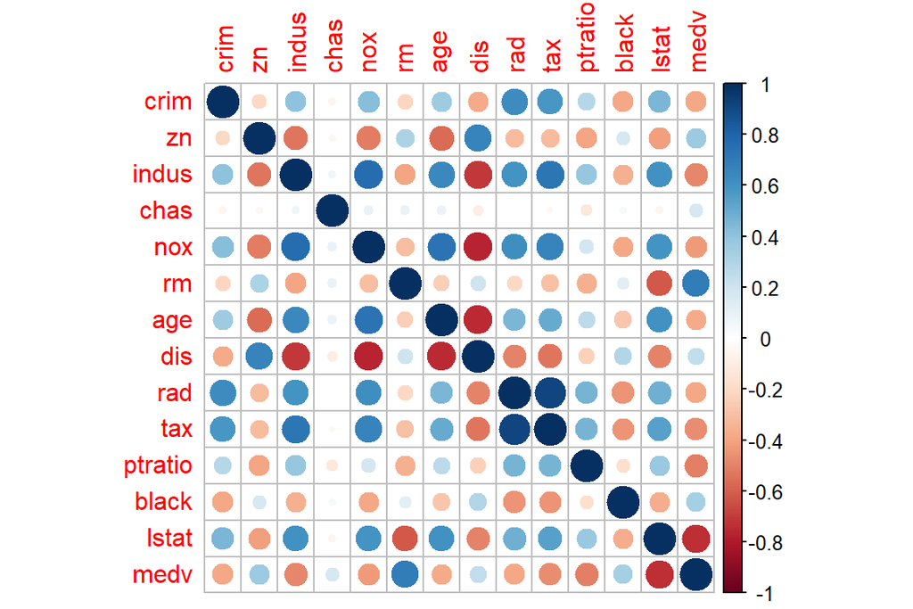

```r
corrplot(cor_matrix, method="circle")
```

Correlation coefficient varies between [-1; 1], with 0 meaning no correlation and 1 or -1 pointing to absolute correlation. For example variable “rad” (index of accessibility to radial highways) is highly correlated with variable “tax” (full-value property-tax rate per $10,000) - with 0.91 value, which is understandable since the proximity to highways may deternime the price for a property and hence its tax. Corrplot is just helping to see the strong correlations with coloured and differently sized circles for better representation of previous results.

```r
#Scaling the dataset and categorising the crime rate variable (crim)
boston_scaled <- scale(Boston)
summary(boston_scaled)
```

```
##       crim                 zn               indus              chas
##  Min.   :-0.419367   Min.   :-0.48724   Min.   :-1.5563   Min.   :-0.2723
##  1st Qu.:-0.410563   1st Qu.:-0.48724   1st Qu.:-0.8668   1st Qu.:-0.2723
##  Median :-0.390280   Median :-0.48724   Median :-0.2109   Median :-0.2723
##  Mean   : 0.000000   Mean   : 0.00000   Mean   : 0.0000   Mean   : 0.0000
##  3rd Qu.: 0.007389   3rd Qu.: 0.04872   3rd Qu.: 1.0150   3rd Qu.:-0.2723
##  Max.   : 9.924110   Max.   : 3.80047   Max.   : 2.4202   Max.   : 3.6648
##       nox                rm               age               dis
##  Min.   :-1.4644   Min.   :-3.8764   Min.   :-2.3331   Min.   :-1.2658
##  1st Qu.:-0.9121   1st Qu.:-0.5681   1st Qu.:-0.8366   1st Qu.:-0.8049
##  Median :-0.1441   Median :-0.1084   Median : 0.3171   Median :-0.2790
##  Mean   : 0.0000   Mean   : 0.0000   Mean   : 0.0000   Mean   : 0.0000
##  3rd Qu.: 0.5981   3rd Qu.: 0.4823   3rd Qu.: 0.9059   3rd Qu.: 0.6617
##  Max.   : 2.7296   Max.   : 3.5515   Max.   : 1.1164   Max.   : 3.9566
##       rad               tax             ptratio            black
##  Min.   :-0.9819   Min.   :-1.3127   Min.   :-2.7047   Min.   :-3.9033
##  1st Qu.:-0.6373   1st Qu.:-0.7668   1st Qu.:-0.4876   1st Qu.: 0.2049
##  Median :-0.5225   Median :-0.4642   Median : 0.2746   Median : 0.3808
##  Mean   : 0.0000   Mean   : 0.0000   Mean   : 0.0000   Mean   : 0.0000
##  3rd Qu.: 1.6596   3rd Qu.: 1.5294   3rd Qu.: 0.8058   3rd Qu.: 0.4332
##  Max.   : 1.6596   Max.   : 1.7964   Max.   : 1.6372   Max.   : 0.4406
##      lstat              medv
##  Min.   :-1.5296   Min.   :-1.9063
##  1st Qu.:-0.7986   1st Qu.:-0.5989
##  Median :-0.1811   Median :-0.1449
##  Mean   : 0.0000   Mean   : 0.0000
##  3rd Qu.: 0.6024   3rd Qu.: 0.2683
##  Max.   : 3.5453   Max.   : 2.9865
```

```r
class(boston_scaled)
```

```
## [1] "matrix" "array"
```

```r
boston_scaled <- as.data.frame(boston_scaled)
bins <- quantile(boston_scaled$crim)
label_cr <- c("low", "med_low", "med_high", "high")
crime <- cut(boston_scaled$crim, breaks = bins, include.lowest = TRUE, labels = label_cr)
table(crime)
```

```
## crime
##      low  med_low med_high     high
##      127      126      126      127
```

```r
boston_scaled <- dplyr::select(boston_scaled, -crim)
boston_scaled <- data.frame(boston_scaled, crime)
```

Here we scaled the dataset for better comparability. ALso replaced crim variable with crime that is categorised on the basis of its quantile points for low, medium low, medium high and high crime rates in the area. Such categorisations may reduce the data and lose some information, yet it might be helpful for interpretation purposes.

```r
#Dividing the dataset on train and test sets
n <- nrow(boston_scaled)
ind <- sample(n,  size = n * 0.8)
train <- boston_scaled[ind,]
test <- boston_scaled[-ind,]
correct_classes <- test$crime
test <- dplyr::select(test, -crime)
```

We split the data to test and train sets, where the train data consists of 80% of cases chosen randomly. Like this we will be able to test the model fit.

```r
#Fitting the linear discriminant analysis on the train set
colnames(boston_scaled)
```

```
##  [1] "zn"      "indus"   "chas"    "nox"     "rm"      "age"     "dis"
##  [8] "rad"     "tax"     "ptratio" "black"   "lstat"   "medv"    "crime"
```

```r
lda.fit <- lda(crime  ~ zn + indus + chas + nox + rm + age + dis + rad + tax + ptratio + black + lstat + medv, data = train)

lda.fit
```

```
## Call:
## lda(crime ~ zn + indus + chas + nox + rm + age + dis + rad +
##     tax + ptratio + black + lstat + medv, data = train)
##
## Prior probabilities of groups:
##       low   med_low  med_high      high
## 0.2450495 0.2574257 0.2549505 0.2425743
##
## Group means:
##                   zn      indus        chas        nox          rm        age
## low       0.95802248 -0.9217965 -0.19279169 -0.8608792  0.43278589 -0.9005927
## med_low  -0.09083281 -0.3428353 -0.08304540 -0.5677726 -0.11005524 -0.3782397
## med_high -0.39399282  0.2563368  0.18636222  0.4123371  0.04032991  0.4684475
## high     -0.48724019  1.0171960 -0.07145661  1.0488615 -0.41095871  0.8224350
##                 dis        rad        tax    ptratio      black       lstat
## low       0.9020531 -0.7057751 -0.7306174 -0.4642281  0.3745363 -0.75540259
## med_low   0.3764277 -0.5379445 -0.4501213 -0.0349782  0.3181313 -0.20393781
## med_high -0.4048432 -0.4187879 -0.2794134 -0.2220732  0.1039770  0.06673355
## high     -0.8591618  1.6373367  1.5134896  0.7798552 -0.7038178  0.87156168
##                  medv
## low       0.492746423
## med_low   0.003855877
## med_high  0.110757688
## high     -0.651064542
##
## Coefficients of linear discriminants:
##                  LD1          LD2         LD3
## zn       0.080848717  0.617243436 -1.12218116
## indus    0.046639869 -0.403009816  0.11082112
## chas    -0.111762007 -0.092398819  0.08234568
## nox      0.341590998 -0.688590797 -1.30461011
## rm      -0.100156369 -0.080416311 -0.19207553
## age      0.312507958 -0.452124509 -0.08040382
## dis     -0.022342595 -0.331223630  0.24680343
## rad      3.164889371  0.790377524 -0.15252441
## tax      0.008666345  0.230262203  0.73105252
## ptratio  0.074680092  0.024315929 -0.29436607
## black   -0.119599864  0.006051564  0.05863008
## lstat    0.201524533 -0.186505250  0.27351922
## medv     0.194369375 -0.338718293 -0.13800604
##
## Proportion of trace:
##    LD1    LD2    LD3
## 0.9449 0.0422 0.0129
```

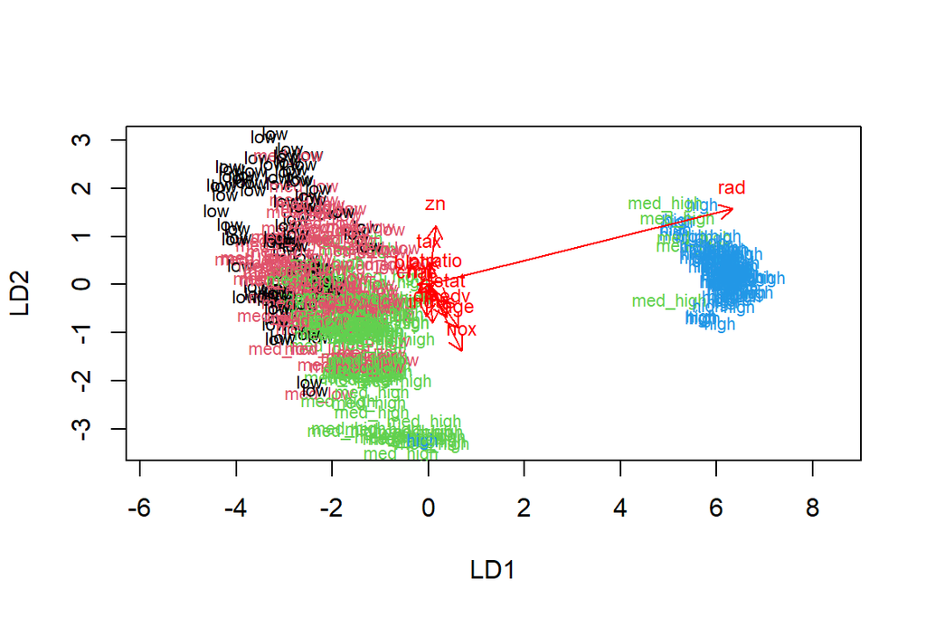

```r
lda.arrows <- function(x, myscale = 1, arrow_heads = 0.1, color = "red", tex = 0.75, choices = c(1,2)){
  heads <- coef(x)
  arrows(x0 = 0, y0 = 0,
         x1 = myscale * heads[,choices[1]],
         y1 = myscale * heads[,choices[2]], col=color, length = arrow_heads)
  text(myscale * heads[,choices], labels = row.names(heads),
       cex = tex, col=color, pos=3)
}

classes <- as.numeric(train$crime)
plot(lda.fit, dimen = 2, col = classes, pch = classes)
lda.arrows(lda.fit, myscale = 2)
```

```r
#How our LDA model performs
lda.pred <- predict(lda.fit, newdata = test)
help(lda.pred)
```

```
## No documentation for 'lda.pred' in specified packages and libraries:
## you could try '??lda.pred'
```

```r
table(correct = correct_classes, predicted = lda.pred$class)
```

```
##           predicted
## correct    low med_low med_high high
##   low       16      10        2    0
##   med_low    4      14        4    0
##   med_high   1       8       13    1
##   high       0       0        0   29
```

What we did is we run the LDA on the train and on test data and compared the results in a crosstab. Table shows that the cases are mostly positioned in the same groups, which shows a relatively good fit

```r
#K-means clustering
set.seed(5)
data("Boston")
boston_scaled <- as.data.frame(scale(Boston))
dist_eu <- dist(boston_scaled)
summary(dist_eu)
```

```
##    Min. 1st Qu.  Median    Mean 3rd Qu.    Max.
##  0.1343  3.4625  4.8241  4.9111  6.1863 14.3970
```

[figure not shown]

```r
km <- kmeans(boston_scaled, centers = 2)
prs <- pairs(boston_scaled, col = km$cluster)
```

```r
prs
```

```r
#fig.width
```

The data is clearly separated to red and black groups, which shows a high relevance of clustering for predictions.

##assignment 6 lognitudinal data##

```r
# Standardise the variable bprs
BPRSL <- BPRSL %>%
  group_by(week) %>%
  mutate(stdbprs = (bprs - mean(bprs)) / sd(bprs)) %>%
  ungroup()

# Glimpse the data
glimpse(BPRSL)
```

```
## Rows: 360
## Columns: 6
## $ treatment <fct> 1, 1, 1, 1, 1, 1, 1, 1, 1, 1, 1, 1, 1, 1, 1, 1, 1, 1, 1, 1, …
## $ subject   <fct> 1, 2, 3, 4, 5, 6, 7, 8, 9, 10, 11, 12, 13, 14, 15, 16, 17, 1…
## $ weeks     <chr> "week0", "week0", "week0", "week0", "week0", "week0", "week0…
## $ bprs      <int> 42, 58, 54, 55, 72, 48, 71, 30, 41, 57, 30, 55, 36, 38, 66, …
## $ week      <int> 0, 0, 0, 0, 0, 0, 0, 0, 0, 0, 0, 0, 0, 0, 0, 0, 0, 0, 0, 0, …
## $ stdbprs   <dbl> -0.4245908, 0.7076513, 0.4245908, 0.4953559, 1.6983632, 0.00…
```

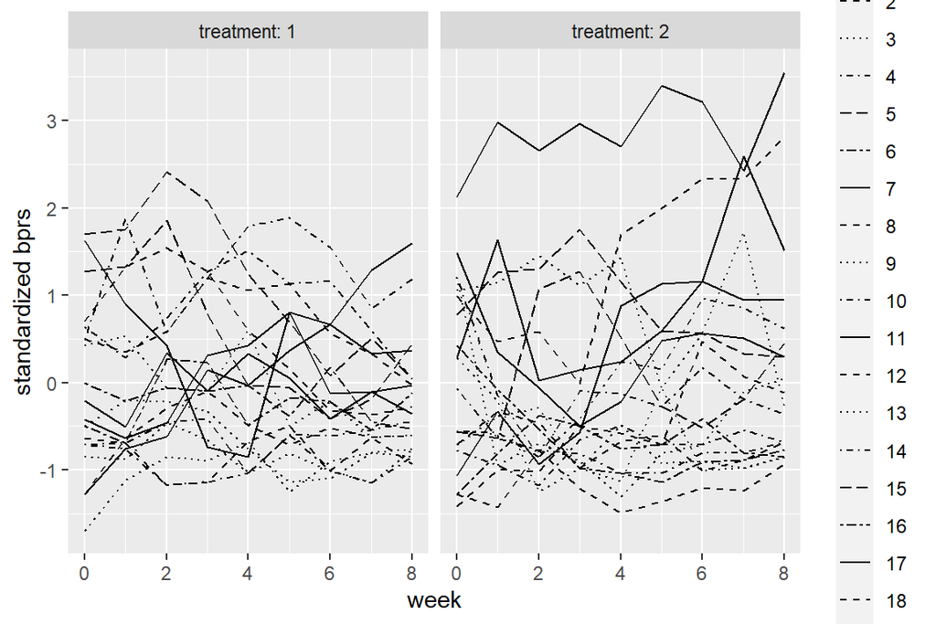

```r
# Plot again  the standardised bprs
library(ggplot2)
ggplot(BPRSL, aes(x = week, y = stdbprs, linetype = subject)) +
  geom_line() +
  scale_linetype_manual(values = rep(1:10, times=4)) +
  facet_grid(. ~ treatment, labeller = label_both) +
  scale_y_continuous(name = "standardized bprs")
```

```r
n <- 20
BPRSS <- BPRSL %>%
  group_by(treatment, week) %>%
  summarise( mean = mean(bprs), se = sd(bprs)/sqrt(n) ) %>%
  ungroup()
# Glimpse the data
glimpse(BPRSS)
```

```
## Rows: 18
## Columns: 4
## $ treatment <fct> 1, 1, 1, 1, 1, 1, 1, 1, 1, 2, 2, 2, 2, 2, 2, 2, 2, 2
## $ week      <int> 0, 1, 2, 3, 4, 5, 6, 7, 8, 0, 1, 2, 3, 4, 5, 6, 7, 8
## $ mean      <dbl> 47.00, 46.80, 43.55, 40.90, 36.60, 32.70, 29.70, 29.80, 29.3…
## $ se        <dbl> 3.041814, 3.470629, 2.685708, 2.511971, 2.186562, 1.741294, …
```

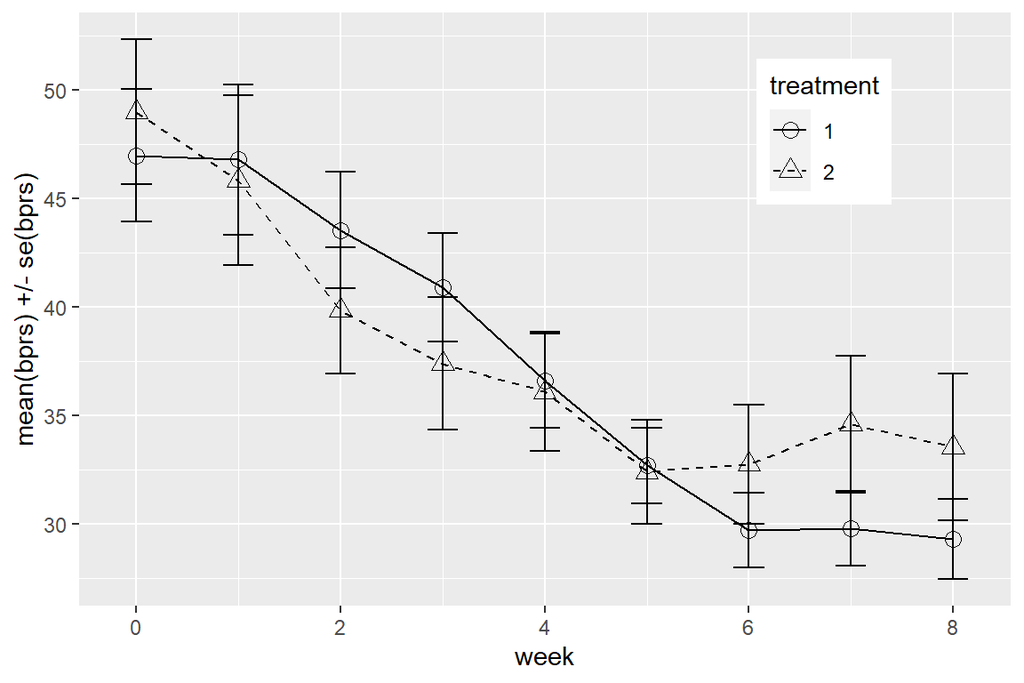

```r
# Plot the mean profiles

library(ggplot2)
ggplot(BPRSS, aes(x = week, y = mean, linetype = treatment, shape = treatment)) +
  geom_line() +
  scale_linetype_manual(values = c(1,2)) +
  geom_point(size=3) +
  scale_shape_manual(values = c(1,2)) +
  geom_errorbar(aes(ymin=mean-se, ymax=mean+se, linetype="1"), width=0.3) +
  theme(legend.position = c(0.8,0.8)) +
  scale_y_continuous(name = "mean(bprs) +/- se(bprs)")
```

```r
#finding aand filtering outliers
# Create a summary data by treatment and subject with mean as the summary variable (ignoring baseline week 0)
BPRSL8S <- BPRSL %>%
  filter(week > 0) %>%
  group_by(treatment, subject) %>%
  summarise( mean=mean(bprs) ) %>%
  ungroup()
```

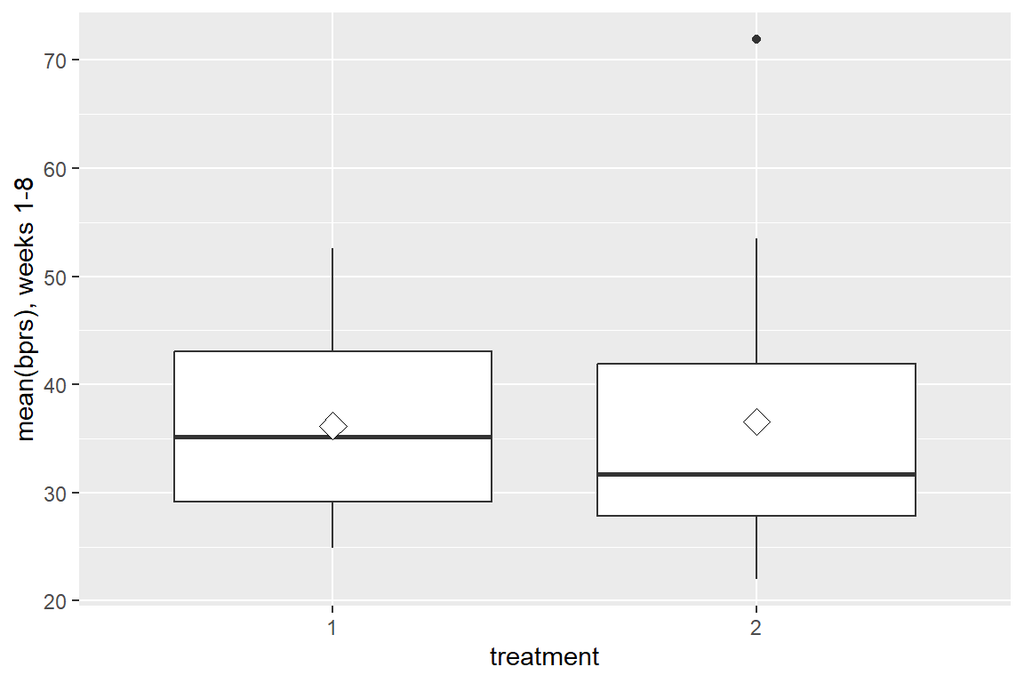

```r
#
ggplot(BPRSL8S, aes(x = treatment, y = mean)) +
  geom_boxplot() +
  stat_summary(fun = "mean", geom = "point", shape=23, size=4, fill = "white") +
  scale_y_continuous(name = "mean(bprs), weeks 1-8")
```

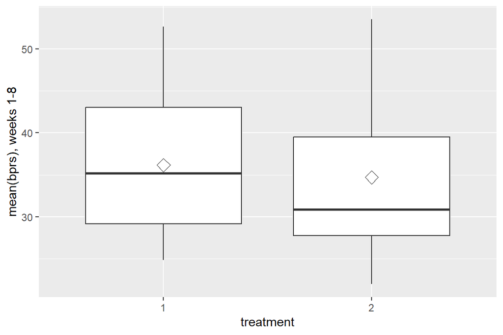

```r
# Create a new data by filtering the outlier and adjust the ggplot code the draw the plot again with the new data
BPRSL8S1 <- filter(BPRSL8S, mean < 60)

library(ggplot2)
ggplot(BPRSL8S1, aes(x = treatment, y = mean)) +
  geom_boxplot() +
  stat_summary(fun = "mean", geom = "point", shape=23, size=4, fill = "white") +
  scale_y_continuous(name = "mean(bprs), weeks 1-8")
```

```r
#filtering out outliers
BPRSL8S1 <- BPRSL8S %>%
  filter(mean < 60)
```

```r
BPRSL8S2 <- BPRSL8S %>%
  mutate(baseline = BPRS$week0)

# Fit the linear model with the mean as the response
fit <- lm(mean ~ baseline + treatment, data = BPRSL8S2)
summary(fit)
```

```
##
## Call:
## lm(formula = mean ~ baseline + treatment, data = BPRSL8S2)
##
## Residuals:
##      Min       1Q   Median       3Q      Max
## -16.1729  -4.5994   0.1088   4.6703  21.0656
##
## Coefficients:
##             Estimate Std. Error t value Pr(>|t|)
## (Intercept) 13.07897    4.55710   2.870  0.00675 **
## baseline     0.49127    0.08943   5.493 3.05e-06 ***
## treatment2  -0.58879    2.49584  -0.236  0.81480
## ---
## Signif. codes:  0 '***' 0.001 '**' 0.01 '*' 0.05 '.' 0.1 ' ' 1
##
## Residual standard error: 7.872 on 37 degrees of freedom
## Multiple R-squared:  0.4494, Adjusted R-squared:  0.4196
## F-statistic:  15.1 on 2 and 37 DF,  p-value: 1.605e-05
```

```r
# Compute the analysis of variance table for the fitted model with anova()
anova(fit)
```

```
## Analysis of Variance Table
##
## Response: mean
##           Df  Sum Sq Mean Sq F value    Pr(>F)
## baseline   1 1868.07 1868.07 30.1437 3.077e-06 ***
## treatment  1    3.45    3.45  0.0557    0.8148
## Residuals 37 2292.97   61.97
## ---
## Signif. codes:  0 '***' 0.001 '**' 0.01 '*' 0.05 '.' 0.1 ' ' 1
```

(more chapters to be added similarly as we proceed with the course!)